# Investigating contextual effects on the production of English probability expressions

Analysis

Michele Herbstritt, Michael Franke

#### Introduction

We tested values of 0, 3, 4, 5, 10 (likelihood of focal outcome, 0 and 10 being control conditions), within subject manipulation of scenario (dual, plural) and within subject manipulation of qud (polar, wh). We measured participants’ choices of the messages ‘certainly not’, ‘probably not’, ‘probably’, ‘certainly’.

```r
library(tidyverse)
library(brms) # bayesian regression models based on STAN
library(bayesplot) # plot estimated posterior coefficients
options(mc.cores = parallel::detectCores()) # multicore parallel computation
```

#### Getting and shaping data

```r
# csv file is the output of preliminary cleaning procedure (exclusion criteria, missing data,...) as reported in clean_explore.Rmd
expdata = readr::read_csv('clean-48workers.csv') %>% mutate(trial=`trial.`) %>%
  filter(kind == "trial") %>%        ## discard training trials
  mutate(trial = trial -3,           ## reset trial counter
         sentExpression = factor(sentExpression, ordered = TRUE,                        ## order response levels wrt semantic strength
                                 levels = c("certNot", "probNot", "prob", "cert")),
         value = as.integer(value)) %>% ## fix data type
  select(id, trial, color, scenario, qud, value, sentExpression, language, comments) ## select necessary columns only
```

#### Analysis

We take a Bayesian approach to ordinal mixed effect regression models.

##### Target model

First, compute posterior coefficients of full model, regressing ordinal factor EXPRESSION (choice frequencies of probability expression) against VALUE, SCENARIO and QUD and all of their potential interactions, as well as the maximal random effects structure (by-participant random intercepts and slopes for all explanatory variables).

```r
fitTarget = brm(formula = sentExpression ~ value * qud * scenario + (1 + value * qud * scenario | id),
                data = expdata, family = cumulative)
```

Let’s inspect posterior of coefficients for target model.

```r
# get posterior
ps = posterior_samples(fitTarget, pars = c("b_value", "b_qudwh", "b_scenarioplural", "b_qudwh:scenarioplural")) %>%
  gather(key = "variable", value = "value") %>% as_tibble

# group by variables of interest and compute posterior means and hdis of coefficients
ps_summary = ps %>% group_by(variable) %>%
  summarize(HDI_lo = coda::HPDinterval(coda::as.mcmc(value))[1],
            mean = mean(value),
            HDI_hi = coda::HPDinterval(coda::as.mcmc(value))[2]) %>%
  ungroup() %>%
  mutate(credibly_different = ifelse(HDI_lo > 0, "bigger", ifelse(HDI_hi < 0, "smaller", "--"))) # label coefficients credibly different than 0

ps_summary %>% show
```

```
## # A tibble: 7 × 5
##                       variable     HDI_lo        mean    HDI_hi
##                          <chr>      <dbl>       <dbl>     <dbl>
## 1                      b_qudwh -2.2706561 -0.01552840 2.3552035
## 2       b_qudwh:scenarioplural -4.1279057 -0.43400231 3.4625436
## 3             b_scenarioplural -5.4923088 -2.52859960 0.2174138
## 4                      b_value  2.4712224  3.11487238 3.6878316
## 5                b_value:qudwh -0.4824854  0.05750049 0.6070437
## 6 b_value:qudwh:scenarioplural -0.9870458 -0.02883124 0.8812356
## 7       b_value:scenarioplural  0.4130090  1.10148895 1.8411197
## # ... with 1 more variables: credibly_different <chr>
```

We can plot posterior estimates for coefficients to better visualize credibility intervals.

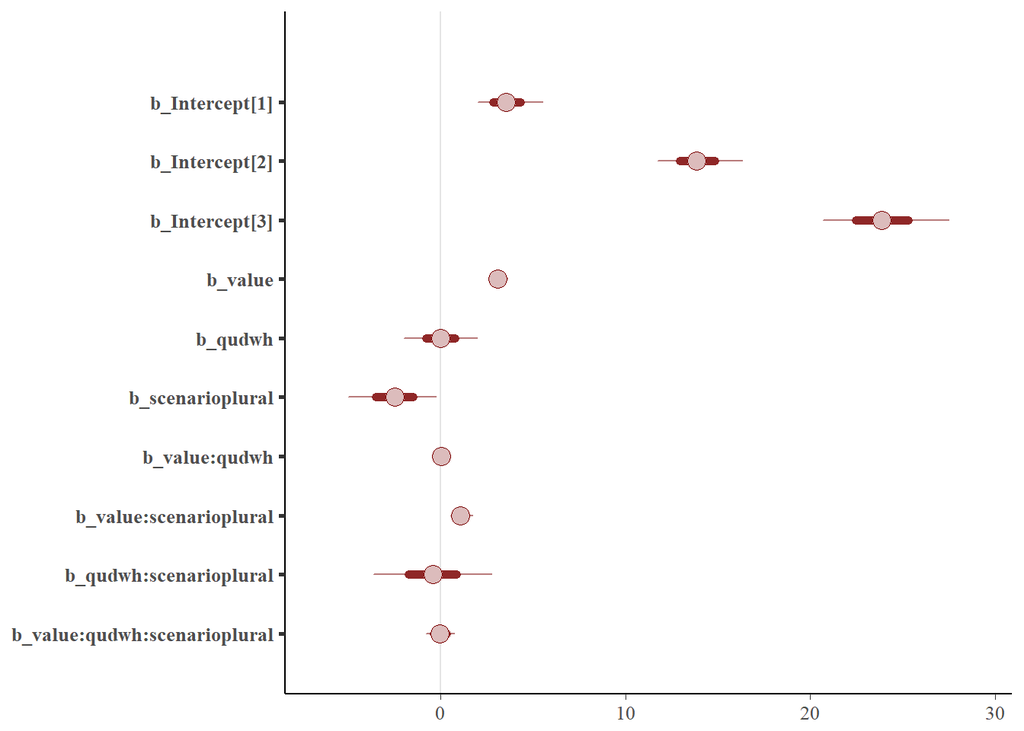

```r
bayesplot::color_scheme_set("red")
bayesplot::mcmc_intervals(as.array(fitTarget), regex_pars = "b_")
```

We notice VALUE has a coefficient credibly bigger than zero, as expected. On the other hand, neither QUD nor SCENARIO have credibly bigger than zero coefficients. Moreover, SCENARIO has a lower than zero coefficient, opposite to what we would expect. A possible interpretation can be put forward looking at the barplots in the clean_explore.Rmd report. In the control conditions 0 and 10, where participants have (mistakenly?) sometimes chosen literally false messages, we can observe that the effect of scenario goes in the direction opposite to what we expected. The other coefficient credibly bigger than zero is the interaction between VALUE and SCENARIO: angain looking at the barplots, there seems to be a tendency of SCENARIO effect in the expected direction, but only present for conditions 3, 4 and 5.

##### Model comparison

We fit simpler models dropping one, two and finally three predictors.

```r
fitNoQUD = brm(formula = sentExpression ~ value * scenario + (1 + value * scenario | id),
                       data = expdata, family = cumulative)
fitNoScenario = brm(formula = sentExpression ~ value * qud + (1 +  value * qud | id),
               data = expdata, family = cumulative, control = list(adapt_delta = 0.9)) # higher adapt_delta to help convergence
```

```r
fitNoValue = brm(formula = sentExpression ~ qud * scenario + (1 +  qud * scenario | id),
                    data = expdata, family = cumulative)
```

```r
fitOnlyQUD = brm(formula = sentExpression ~ qud + (1 +  qud | id),
                 data = expdata, family = cumulative)
```

```r
fitOnlyScenario = brm(formula = sentExpression ~ scenario + (1 +  scenario | id),
                      data = expdata, family = cumulative)
fitOnlyValue = brm(formula = sentExpression ~ value + (1 +  value | id),
                   data = expdata, family = cumulative, control = list(adapt_delta = 0.9)) # higher adapt_delta to help convergence
fitIntercept = brm(formula = sentExpression ~ 1,
                   data = expdata, family = cumulative)
```

We compare models by LOO-IC.

```r
loofit <- loo(fitTarget,
             fitNoQUD, fitNoScenario, fitNoValue,
             fitOnlyValue, fitOnlyScenario, fitOnlyQUD,
             fitIntercept)
loofit %>% show # lower is better
```

```
##                                    LOOIC    SE
## fitTarget                         531.93 66.02
## fitNoQUD                          513.70 62.20
## fitNoScenario                     574.42 57.13
## fitNoValue                       1930.43 28.98
## fitOnlyValue                      564.83 55.47
## fitOnlyScenario                  1923.45 28.90
## fitOnlyQUD                       1928.19 27.96
## fitIntercept                     1922.25 27.70
## fitTarget - fitNoQUD               18.23  6.98
## fitTarget - fitNoScenario         -42.48 18.39
## fitTarget - fitNoValue          -1398.49 72.43
## fitTarget - fitOnlyValue          -32.89 19.19
## fitTarget - fitOnlyScenario     -1391.51 72.34
## fitTarget - fitOnlyQUD          -1396.26 72.23
## fitTarget - fitIntercept        -1390.31 71.97
## fitNoQUD - fitNoScenario          -60.71 17.78
## fitNoQUD - fitNoValue           -1416.72 68.84
## fitNoQUD - fitOnlyValue           -51.12 17.86
## fitNoQUD - fitOnlyScenario      -1409.74 68.76
## fitNoQUD - fitOnlyQUD           -1414.49 68.62
## fitNoQUD - fitIntercept         -1408.54 68.37
## fitNoScenario - fitNoValue      -1356.01 65.45
## fitNoScenario - fitOnlyValue        9.59  2.55
## fitNoScenario - fitOnlyScenario -1349.03 65.38
## fitNoScenario - fitOnlyQUD      -1353.78 64.92
## fitNoScenario - fitIntercept    -1347.83 64.67
## fitNoValue - fitOnlyValue        1365.60 63.94
## fitNoValue - fitOnlyScenario        6.98  1.68
## fitNoValue - fitOnlyQUD             2.23  4.68
## fitNoValue - fitIntercept           8.18  5.00
## fitOnlyValue - fitOnlyScenario  -1358.62 63.86
## fitOnlyValue - fitOnlyQUD       -1363.37 63.39
## fitOnlyValue - fitIntercept     -1357.42 63.14
## fitOnlyScenario - fitOnlyQUD       -4.75  4.42
## fitOnlyScenario - fitIntercept      1.20  4.58
## fitOnlyQUD - fitIntercept           5.95  1.15
```

It appears that the model dropping QUD as predictor is the best in terms of LOO-IC. Let’s visualize its coefficients.

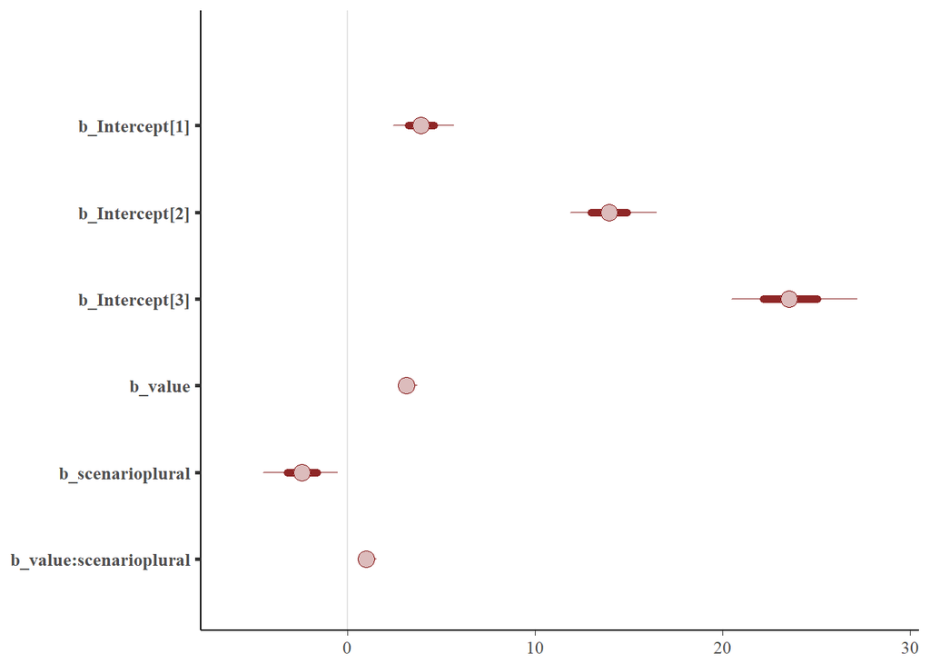

```r
bayesplot::mcmc_intervals(as.array(fitNoQUD), regex_pars = "b_")
```

#### Additional analysis

What follows is to be considered as an exploratory analysis beyond the scope of the pre-registered project. We explore what happens to the regression model if we exclude more data on the basis of stricter constraint(s) to the control conditions.

First, we try a rather crude filter and simply exclude all data obtained in the control conditions.

```r
# exclude all data points from the control conditions and fit the full model
fitTarget_restricted_crude = brm(formula = sentExpression ~ value * qud * scenario + (1 + value * qud * scenario | id),
                data = filter(expdata, ! value %in% c(0,10)), family = cumulative)
```

```r
# summary of coefficients
ps_restricted_crude = posterior_samples(fitTarget_restricted_crude, pars = c("b_value", "b_qudwh", "b_scenarioplural", "b_qudwh:scenarioplural")) %>%
  gather(key = "variable", value = "value") %>% as_tibble
ps_summary_restricted_crude = ps_restricted_crude %>% group_by(variable) %>%
  summarize(HDI_lo = coda::HPDinterval(coda::as.mcmc(value))[1],
            mean = mean(value),
            HDI_hi = coda::HPDinterval(coda::as.mcmc(value))[2]) %>%
  ungroup() %>%
  mutate(credibly_different = ifelse(HDI_lo > 0, "bigger", ifelse(HDI_hi < 0, "smaller", "--")))

ps_summary_restricted_crude %>% show
```

```
## # A tibble: 7 × 5
##                       variable       HDI_lo       mean      HDI_hi
##                          <chr>        <dbl>      <dbl>       <dbl>
## 1                      b_qudwh   0.26161629  10.649710 21.32091750
## 2       b_qudwh:scenarioplural -24.52882578 -12.050892 -0.24854444
## 3             b_scenarioplural   7.14126895  17.818687 29.44970800
## 4                      b_value   6.66137677   9.560672 13.25652539
## 5                b_value:qudwh  -4.73641030  -2.326564 -0.02509776
## 6 b_value:qudwh:scenarioplural  -0.09928135   2.553099  5.46514227
## 7       b_value:scenarioplural  -5.58819383  -3.203101 -0.73955016
## # ... with 1 more variables: credibly_different <chr>
```

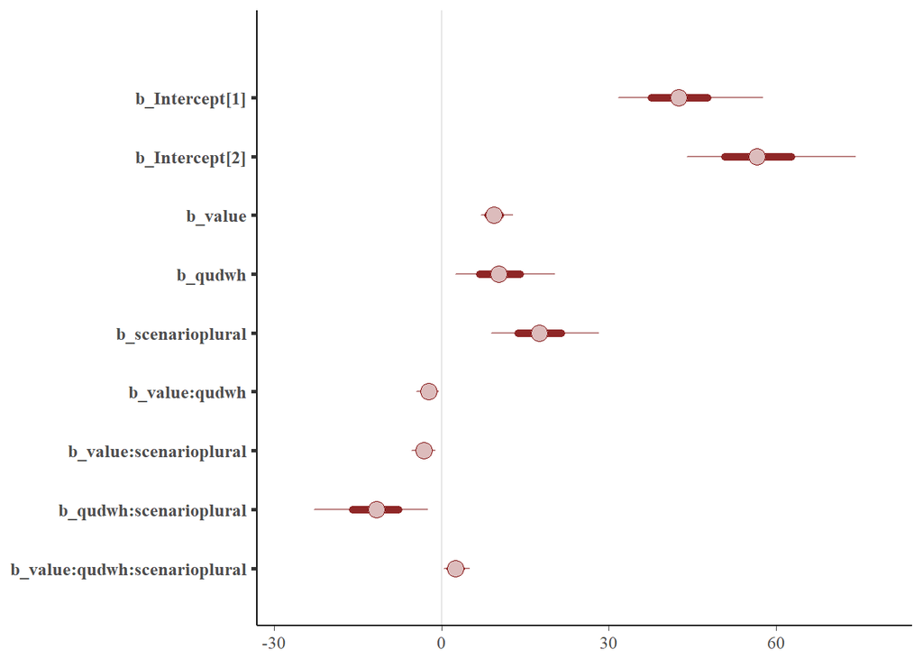

```r
# visualization
bayesplot::mcmc_intervals(as.array(fitTarget_restricted_crude), regex_pars = "b_")
```

Here we can observe coefficients more in line with our expectations: VALUE and SCENARIO have coefficients credibly bigger than zero. However, the fact that QUD too has a coefficient credibly different than zero after excluding the control conditions is (albeit in line with theoretical hypothesis), a little puzzling. Looking a the barplot in the clean_explore.Rmd we can observe perhaps a small tendency of QUD effect only in the dual scenario condition, whereas no such tendency is observable in the plural condition. This difference can be what drives down the coefficient for the interaction between QUD and SCENARIO, which appears to be credibly smaller than zero.

Second, we try a lighter approach, excluding only the wrong answers to the control conditions.

```r
# exclude 'wrong' asnwers to the control conditions and fit the full model
fitTarget_restricted_light = brm(formula = sentExpression ~ value * qud * scenario + (1 + value * qud * scenario | id),
                           data = filter(expdata, ! (value == 0 & sentExpression != "certNot") &
                                           ! (value == 10 & sentExpression != "cert")),
                           family = cumulative)
```

```r
# summary of coefficients
ps_restricted_light = posterior_samples(fitTarget_restricted_light, pars = c("b_value", "b_qudwh", "b_scenarioplural", "b_qudwh:scenarioplural")) %>%
  gather(key = "variable", value = "value") %>% as_tibble
ps_summary_restricted_light = ps_restricted_light %>% group_by(variable) %>%
  summarize(HDI_lo = coda::HPDinterval(coda::as.mcmc(value))[1],
            mean = mean(value),
            HDI_hi = coda::HPDinterval(coda::as.mcmc(value))[2]) %>%
  ungroup() %>%
  mutate(credibly_different = ifelse(HDI_lo > 0, "bigger", ifelse(HDI_hi < 0, "smaller", "--")))

ps_summary_restricted_light %>% show
```

```
## # A tibble: 7 × 5
##                       variable      HDI_lo       mean    HDI_hi
##                          <chr>       <dbl>      <dbl>     <dbl>
## 1                      b_qudwh  -2.8229363  2.5498490 8.1148142
## 2       b_qudwh:scenarioplural -10.1266018 -3.3306228 2.9683666
## 3             b_scenarioplural  -2.4513455  3.1484959 8.2513765
## 4                      b_value   4.6310515  6.1473966 7.8430065
## 5                b_value:qudwh  -1.7669698 -0.5492059 0.7770588
## 6 b_value:qudwh:scenarioplural  -0.8795698  0.6181369 2.2096197
## 7       b_value:scenarioplural  -1.2374832  0.0193081 1.2407112
## # ... with 1 more variables: credibly_different <chr>
```

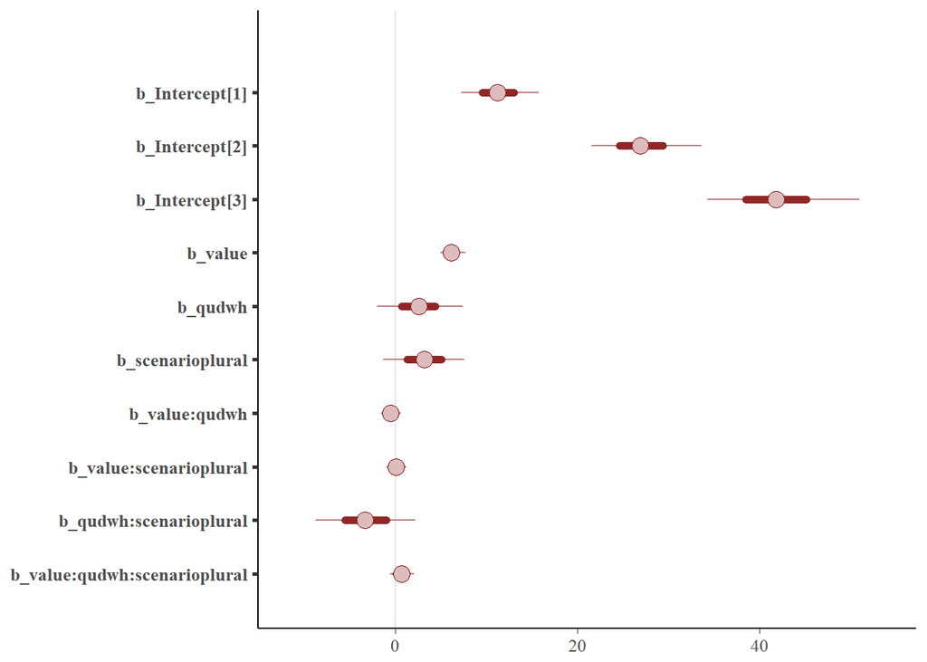

```r
# visualization
bayesplot::mcmc_intervals(as.array(fitTarget_restricted_light), regex_pars = "b_")
```

We can observe the same tendency as before, except here no coefficient other than VALUE is credibly different than zero.

Finally, we try using data exclusively from participants who got every control right.

```r
# get data and shape, the csv is produced in clean_explore.Rmd
perfectdata = readr::read_csv('perfect-43workers.csv') %>% mutate(trial=`trial.`) %>%
  filter(kind == "trial") %>%        ## discard training trials
  mutate(trial = trial -3,           ## reset trial counter
         sentExpression = factor(sentExpression, ordered = TRUE,                        ## order response levels
                                 levels = c("certNot", "probNot", "prob", "cert")),
         value = as.integer(value)) %>%
  select(id, trial, color, scenario, qud, value, sentExpression, language, comments)
```

```r
# full model
fitTarget_restricted_hardest = brm(formula = sentExpression ~ value * qud * scenario + (1 + value * qud * scenario | id),
                                 data = perfectdata, family = cumulative)
```

```r
# summary of coefficients
ps_restricted_hardest = posterior_samples(fitTarget_restricted_hardest, pars = c("b_value", "b_qudwh", "b_scenarioplural", "b_qudwh:scenarioplural")) %>%
  gather(key = "variable", value = "value") %>% as_tibble
ps_summary_restricted_hardest = ps_restricted_hardest %>% group_by(variable) %>%
  summarize(HDI_lo = coda::HPDinterval(coda::as.mcmc(value))[1],
            mean = mean(value),
            HDI_hi = coda::HPDinterval(coda::as.mcmc(value))[2]) %>%
  ungroup() %>%
  mutate(credibly_different = ifelse(HDI_lo > 0, "bigger", ifelse(HDI_hi < 0, "smaller", "--")))

ps_summary_restricted_hardest %>% show
```

```
## # A tibble: 7 × 5
##                       variable     HDI_lo       mean     HDI_hi
##                          <chr>      <dbl>      <dbl>      <dbl>
## 1                      b_qudwh  -3.047324  3.6590675 10.0999384
## 2       b_qudwh:scenarioplural -10.953725 -3.0908558  4.9917293
## 3             b_scenarioplural  -5.850111  1.5244803  8.1372809
## 4                      b_value   4.583195  6.3029728  8.0995611
## 5                b_value:qudwh  -2.305703 -0.7669061  0.7060464
## 6 b_value:qudwh:scenarioplural  -1.252172  0.6224015  2.4285238
## 7       b_value:scenarioplural  -1.090560  0.4931271  2.1793980
## # ... with 1 more variables: credibly_different <chr>
```

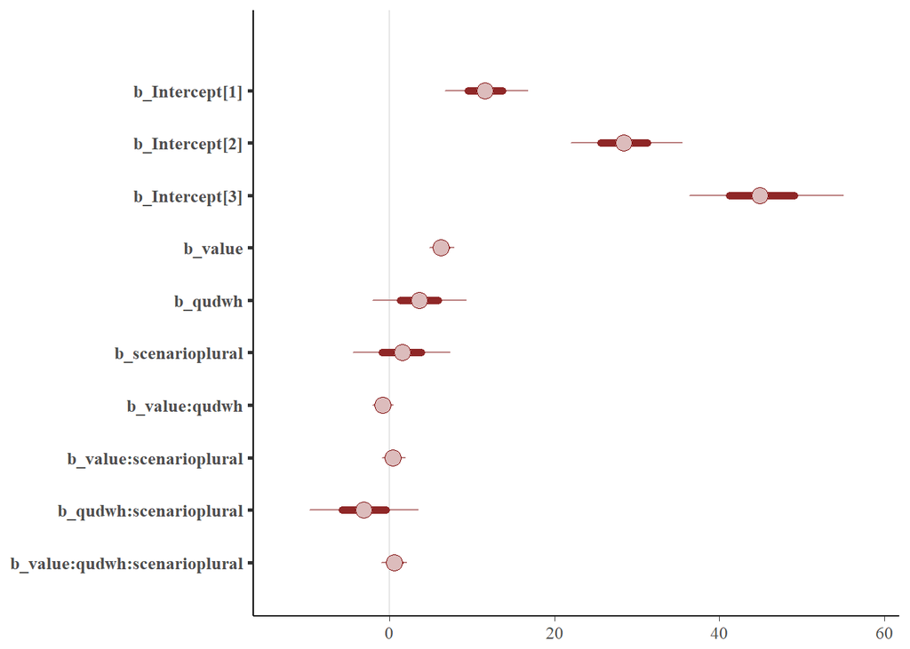

```r
# visualization
bayesplot::mcmc_intervals(as.array(fitTarget_restricted_hardest), regex_pars = "b_")
```

The same observation applies here.